# Risk Factor Analysis

## Outcome Variable

**Outcome Variable:** ever_stunted

## Predictor Variables

**Intervention Variable:** predfeed6

**Adjustment Set:**

- arm
- month
- brthmon
- W_mage
- meducyrs
- feducyrs
- hhwealth_quart
- hfoodsec
- W_mhtcm
- W_mwtkg
- W_mbmi
- vagbrth
- W_gagebrth
- W_birthwt
- W_birthlen
- W_nrooms
- W_nchldlt5
- W_parity
- impfloor
- impsan
- safeh20
- delta_W_mage
- delta_meducyrs
- delta_feducyrs
- delta_hhwealth_quart
- delta_hfoodsec
- delta_W_mhtcm
- delta_W_mwtkg
- delta_W_mbmi
- delta_vagbrth
- delta_W_gagebrth
- delta_W_birthwt
- delta_W_birthlen
- delta_W_nrooms
- delta_W_nchldlt5
- delta_W_parity
- delta_impfloor
- delta_impsan
- delta_safeh20

## Stratifying Variables

The analysis was stratified on these variable(s):

- agecat
- studyid
- country

## Data Summary

| agecat | studyid | country | predfeed6 | ever_stunted | n_cell | n |
| --- | --- | --- | --- | --- | --- | --- |
| 0-24 months (no birth st.) | EE | PAKISTAN | 1 | 0 | 4 | 27 |
| 0-24 months (no birth st.) | EE | PAKISTAN | 1 | 1 | 19 | 27 |
| 0-24 months (no birth st.) | EE | PAKISTAN | 0 | 0 | 2 | 27 |
| 0-24 months (no birth st.) | EE | PAKISTAN | 0 | 1 | 2 | 27 |
| 0-24 months (no birth st.) | GMS-Nepal | NEPAL | 1 | 0 | 130 | 471 |
| 0-24 months (no birth st.) | GMS-Nepal | NEPAL | 1 | 1 | 222 | 471 |
| 0-24 months (no birth st.) | GMS-Nepal | NEPAL | 0 | 0 | 34 | 471 |
| 0-24 months (no birth st.) | GMS-Nepal | NEPAL | 0 | 1 | 85 | 471 |
| 0-24 months (no birth st.) | JiVitA-3 | BANGLADESH | 1 | 0 | 6247 | 10809 |
| 0-24 months (no birth st.) | JiVitA-3 | BANGLADESH | 1 | 1 | 2191 | 10809 |
| 0-24 months (no birth st.) | JiVitA-3 | BANGLADESH | 0 | 0 | 1776 | 10809 |
| 0-24 months (no birth st.) | JiVitA-3 | BANGLADESH | 0 | 1 | 595 | 10809 |
| 0-24 months (no birth st.) | JiVitA-4 | BANGLADESH | 1 | 0 | 1565 | 3397 |
| 0-24 months (no birth st.) | JiVitA-4 | BANGLADESH | 1 | 1 | 1125 | 3397 |
| 0-24 months (no birth st.) | JiVitA-4 | BANGLADESH | 0 | 0 | 393 | 3397 |
| 0-24 months (no birth st.) | JiVitA-4 | BANGLADESH | 0 | 1 | 314 | 3397 |
| 0-24 months (no birth st.) | LCNI-5 | MALAWI | 1 | 0 | 18 | 175 |
| 0-24 months (no birth st.) | LCNI-5 | MALAWI | 1 | 1 | 12 | 175 |
| 0-24 months (no birth st.) | LCNI-5 | MALAWI | 0 | 0 | 83 | 175 |
| 0-24 months (no birth st.) | LCNI-5 | MALAWI | 0 | 1 | 62 | 175 |
| 0-24 months (no birth st.) | MAL-ED | BANGLADESH | 1 | 0 | 32 | 195 |
| 0-24 months (no birth st.) | MAL-ED | BANGLADESH | 1 | 1 | 40 | 195 |
| 0-24 months (no birth st.) | MAL-ED | BANGLADESH | 0 | 0 | 58 | 195 |
| 0-24 months (no birth st.) | MAL-ED | BANGLADESH | 0 | 1 | 65 | 195 |
| 0-24 months (no birth st.) | MAL-ED | BRAZIL | 1 | 0 | 20 | 185 |
| 0-24 months (no birth st.) | MAL-ED | BRAZIL | 1 | 1 | 4 | 185 |
| 0-24 months (no birth st.) | MAL-ED | BRAZIL | 0 | 0 | 134 | 185 |
| 0-24 months (no birth st.) | MAL-ED | BRAZIL | 0 | 1 | 27 | 185 |
| 0-24 months (no birth st.) | MAL-ED | INDIA | 1 | 0 | 1 | 185 |
| 0-24 months (no birth st.) | MAL-ED | INDIA | 1 | 1 | 7 | 185 |

[output cut: 126 more lines]

The following strata were considered:

- agecat: 0-24 months (no birth st.), studyid: EE, country: PAKISTAN
- agecat: 0-24 months (no birth st.), studyid: GMS-Nepal, country: NEPAL
- agecat: 0-24 months (no birth st.), studyid: JiVitA-3, country: BANGLADESH
- agecat: 0-24 months (no birth st.), studyid: JiVitA-4, country: BANGLADESH
- agecat: 0-24 months (no birth st.), studyid: LCNI-5, country: MALAWI
- agecat: 0-24 months (no birth st.), studyid: MAL-ED, country: BANGLADESH
- agecat: 0-24 months (no birth st.), studyid: MAL-ED, country: BRAZIL
- agecat: 0-24 months (no birth st.), studyid: MAL-ED, country: INDIA
- agecat: 0-24 months (no birth st.), studyid: MAL-ED, country: NEPAL
- agecat: 0-24 months (no birth st.), studyid: MAL-ED, country: PERU
- agecat: 0-24 months (no birth st.), studyid: MAL-ED, country: SOUTH AFRICA
- agecat: 0-24 months (no birth st.), studyid: MAL-ED, country: TANZANIA, UNITED REPUBLIC OF
- agecat: 0-24 months (no birth st.), studyid: SAS-FoodSuppl, country: INDIA
- agecat: 0-6 months (no birth st.), studyid: EE, country: PAKISTAN
- agecat: 0-6 months (no birth st.), studyid: GMS-Nepal, country: NEPAL
- agecat: 0-6 months (no birth st.), studyid: JiVitA-3, country: BANGLADESH
- agecat: 0-6 months (no birth st.), studyid: JiVitA-4, country: BANGLADESH
- agecat: 0-6 months (no birth st.), studyid: LCNI-5, country: MALAWI
- agecat: 0-6 months (no birth st.), studyid: MAL-ED, country: BANGLADESH
- agecat: 0-6 months (no birth st.), studyid: MAL-ED, country: BRAZIL
- agecat: 0-6 months (no birth st.), studyid: MAL-ED, country: INDIA
- agecat: 0-6 months (no birth st.), studyid: MAL-ED, country: NEPAL
- agecat: 0-6 months (no birth st.), studyid: MAL-ED, country: PERU
- agecat: 0-6 months (no birth st.), studyid: MAL-ED, country: SOUTH AFRICA
- agecat: 0-6 months (no birth st.), studyid: MAL-ED, country: TANZANIA, UNITED REPUBLIC OF
- agecat: 0-6 months (no birth st.), studyid: SAS-FoodSuppl, country: INDIA
- agecat: 6-24 months, studyid: EE, country: PAKISTAN
- agecat: 6-24 months, studyid: GMS-Nepal, country: NEPAL
- agecat: 6-24 months, studyid: JiVitA-3, country: BANGLADESH
- agecat: 6-24 months, studyid: JiVitA-4, country: BANGLADESH
- agecat: 6-24 months, studyid: LCNI-5, country: MALAWI
- agecat: 6-24 months, studyid: MAL-ED, country: BANGLADESH
- agecat: 6-24 months, studyid: MAL-ED, country: BRAZIL
- agecat: 6-24 months, studyid: MAL-ED, country: INDIA
- agecat: 6-24 months, studyid: MAL-ED, country: NEPAL
- agecat: 6-24 months, studyid: MAL-ED, country: PERU
- agecat: 6-24 months, studyid: MAL-ED, country: SOUTH AFRICA
- agecat: 6-24 months, studyid: MAL-ED, country: TANZANIA, UNITED REPUBLIC OF
- agecat: 6-24 months, studyid: SAS-FoodSuppl, country: INDIA

### Dropped Strata

Some strata were dropped due to rare outcomes:

- agecat: 0-24 months (no birth st.), studyid: EE, country: PAKISTAN
- agecat: 0-24 months (no birth st.), studyid: MAL-ED, country: BRAZIL
- agecat: 0-24 months (no birth st.), studyid: MAL-ED, country: INDIA
- agecat: 0-24 months (no birth st.), studyid: MAL-ED, country: SOUTH AFRICA
- agecat: 0-24 months (no birth st.), studyid: MAL-ED, country: TANZANIA, UNITED REPUBLIC OF
- agecat: 0-24 months (no birth st.), studyid: SAS-FoodSuppl, country: INDIA
- agecat: 0-6 months (no birth st.), studyid: EE, country: PAKISTAN
- agecat: 0-6 months (no birth st.), studyid: LCNI-5, country: MALAWI
- agecat: 0-6 months (no birth st.), studyid: MAL-ED, country: BRAZIL
- agecat: 0-6 months (no birth st.), studyid: MAL-ED, country: INDIA
- agecat: 0-6 months (no birth st.), studyid: MAL-ED, country: NEPAL
- agecat: 0-6 months (no birth st.), studyid: MAL-ED, country: SOUTH AFRICA
- agecat: 0-6 months (no birth st.), studyid: MAL-ED, country: TANZANIA, UNITED REPUBLIC OF
- agecat: 0-6 months (no birth st.), studyid: SAS-FoodSuppl, country: INDIA
- agecat: 6-24 months, studyid: EE, country: PAKISTAN
- agecat: 6-24 months, studyid: MAL-ED, country: BRAZIL
- agecat: 6-24 months, studyid: MAL-ED, country: INDIA
- agecat: 6-24 months, studyid: MAL-ED, country: SOUTH AFRICA
- agecat: 6-24 months, studyid: MAL-ED, country: TANZANIA, UNITED REPUBLIC OF
- agecat: 6-24 months, studyid: SAS-FoodSuppl, country: INDIA

## Methods Detail

We’re interested in the causal parameters $E[Y_a]$ for all values of $a \in \mathcal{A}$. These parameters represent the mean outcome if, possibly contrary to fact, we intervened to set all units to have $A=a$. Under the randomization and positivity assumptions, these are identified by the statistical parameters $\psi_a=E_W[E_{Y|A,W}(Y|A=a,W)]$. In addition, we’re interested in the mean of $Y$, $E[Y]$ under no intervention (the observed mean). We will estimate these parameters by using SuperLearner to fit the relevant likelihood factors – $E_{Y|A,W}(Y|A=a,W)$ and $p(A=a|W)$, and then updating our likelihood fit using a joint TMLE.

For unadjusted analyses ($W=\{\}$), initial likelihoods were estimated using Lrnr_glm to estimate the simple $E(Y|A)$ and Lrnr_mean to estimate $p(A)$. For adjusted analyses, a small library containing Lrnr_glmnet, Lrnr_xgboost, and Lrnr_mean was used.

Having estimated these parameters, we will then use the delta method to estimate relative risks and attributable risks relative to a prespecified baseline level of $A$.

# Results Detail

## Results Plots

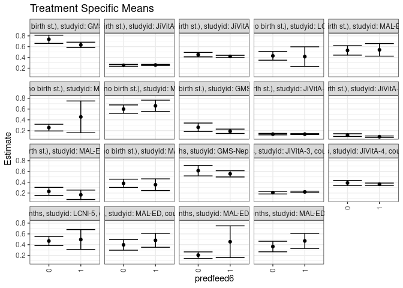

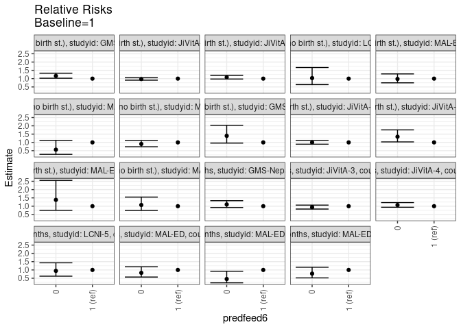

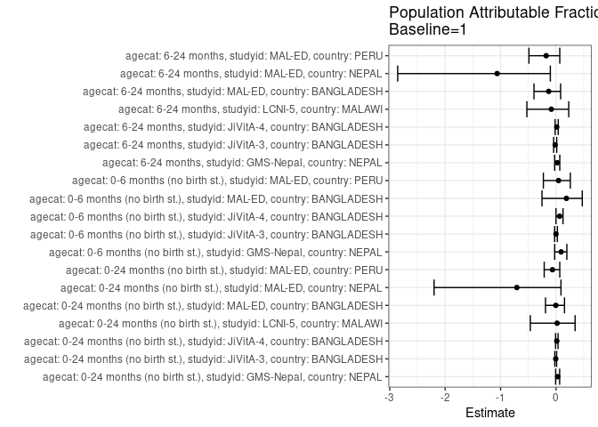

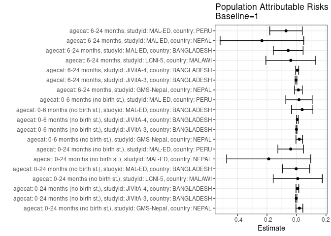

## Results Table

### Parameter: TSM

| agecat | studyid | country | intervention_level | baseline_level | estimate | ci_lower | ci_upper |
| --- | --- | --- | --- | --- | --- | --- | --- |
| 0-24 months (no birth st.) | GMS-Nepal | NEPAL | 1 | NA | 0.6320713 | 0.5817139 | 0.6824288 |
| 0-24 months (no birth st.) | GMS-Nepal | NEPAL | 0 | NA | 0.7363569 | 0.6601287 | 0.8125852 |
| 0-24 months (no birth st.) | JiVitA-3 | BANGLADESH | 1 | NA | 0.2590927 | 0.2480473 | 0.2701381 |
| 0-24 months (no birth st.) | JiVitA-3 | BANGLADESH | 0 | NA | 0.2530798 | 0.2358535 | 0.2703062 |
| 0-24 months (no birth st.) | JiVitA-4 | BANGLADESH | 1 | NA | 0.4173381 | 0.3955088 | 0.4391675 |
| 0-24 months (no birth st.) | JiVitA-4 | BANGLADESH | 0 | NA | 0.4510270 | 0.4096251 | 0.4924290 |
| 0-24 months (no birth st.) | LCNI-5 | MALAWI | 1 | NA | 0.4142887 | 0.2317616 | 0.5968159 |
| 0-24 months (no birth st.) | LCNI-5 | MALAWI | 0 | NA | 0.4288006 | 0.3478825 | 0.5097186 |
| 0-24 months (no birth st.) | MAL-ED | BANGLADESH | 1 | NA | 0.5404673 | 0.4235986 | 0.6573360 |
| 0-24 months (no birth st.) | MAL-ED | BANGLADESH | 0 | NA | 0.5300451 | 0.4423319 | 0.6177584 |
| 0-24 months (no birth st.) | MAL-ED | NEPAL | 1 | NA | 0.4545455 | 0.1595511 | 0.7495398 |
| 0-24 months (no birth st.) | MAL-ED | NEPAL | 0 | NA | 0.2553191 | 0.1928321 | 0.3178062 |
| 0-24 months (no birth st.) | MAL-ED | PERU | 1 | NA | 0.6596265 | 0.5542839 | 0.7649692 |
| 0-24 months (no birth st.) | MAL-ED | PERU | 0 | NA | 0.5985930 | 0.5204604 | 0.6767256 |
| 0-6 months (no birth st.) | GMS-Nepal | NEPAL | 1 | NA | 0.1868998 | 0.1460531 | 0.2277464 |
| 0-6 months (no birth st.) | GMS-Nepal | NEPAL | 0 | NA | 0.2608909 | 0.1813994 | 0.3403824 |
| 0-6 months (no birth st.) | JiVitA-3 | BANGLADESH | 1 | NA | 0.1346259 | 0.1263490 | 0.1429029 |
| 0-6 months (no birth st.) | JiVitA-3 | BANGLADESH | 0 | NA | 0.1343040 | 0.1211829 | 0.1474250 |
| 0-6 months (no birth st.) | JiVitA-4 | BANGLADESH | 1 | NA | 0.0865558 | 0.0729777 | 0.1001340 |
| 0-6 months (no birth st.) | JiVitA-4 | BANGLADESH | 0 | NA | 0.1163658 | 0.0909143 | 0.1418172 |
| 0-6 months (no birth st.) | MAL-ED | BANGLADESH | 1 | NA | 0.1665666 | 0.0790751 | 0.2540582 |
| 0-6 months (no birth st.) | MAL-ED | BANGLADESH | 0 | NA | 0.2300413 | 0.1558463 | 0.3042363 |
| 0-6 months (no birth st.) | MAL-ED | PERU | 1 | NA | 0.3543611 | 0.2460475 | 0.4626747 |
| 0-6 months (no birth st.) | MAL-ED | PERU | 0 | NA | 0.3800407 | 0.3032073 | 0.4568740 |
| 6-24 months | GMS-Nepal | NEPAL | 1 | NA | 0.5560984 | 0.4981313 | 0.6140656 |
| 6-24 months | GMS-Nepal | NEPAL | 0 | NA | 0.6147563 | 0.5177898 | 0.7117228 |
| 6-24 months | JiVitA-3 | BANGLADESH | 1 | NA | 0.2203176 | 0.2069404 | 0.2336948 |
| 6-24 months | JiVitA-3 | BANGLADESH | 0 | NA | 0.2066516 | 0.1820209 | 0.2312824 |
| 6-24 months | JiVitA-4 | BANGLADESH | 1 | NA | 0.3629431 | 0.3412039 | 0.3846822 |
| 6-24 months | JiVitA-4 | BANGLADESH | 0 | NA | 0.3870357 | 0.3403307 | 0.4337407 |
| 6-24 months | LCNI-5 | MALAWI | 1 | NA | 0.4952746 | 0.3101118 | 0.6804374 |
| 6-24 months | LCNI-5 | MALAWI | 0 | NA | 0.4678235 | 0.3830853 | 0.5525617 |
| 6-24 months | MAL-ED | BANGLADESH | 1 | NA | 0.4809015 | 0.3515637 | 0.6102393 |
| 6-24 months | MAL-ED | BANGLADESH | 0 | NA | 0.3968694 | 0.2973524 | 0.4963863 |
| 6-24 months | MAL-ED | NEPAL | 1 | NA | 0.4545455 | 0.1594991 | 0.7495918 |
| 6-24 months | MAL-ED | NEPAL | 0 | NA | 0.2057143 | 0.1456633 | 0.2657653 |
| 6-24 months | MAL-ED | PERU | 1 | NA | 0.4695011 | 0.3294454 | 0.6095568 |
| 6-24 months | MAL-ED | PERU | 0 | NA | 0.3652922 | 0.2673634 | 0.4632211 |

### Parameter: E(Y)

| agecat | studyid | country | intervention_level | baseline_level | estimate | ci_lower | ci_upper |
| --- | --- | --- | --- | --- | --- | --- | --- |
| 0-24 months (no birth st.) | GMS-Nepal | NEPAL | NA | NA | 0.6518047 | 0.6087352 | 0.6948741 |
| 0-24 months (no birth st.) | JiVitA-3 | BANGLADESH | NA | NA | 0.2577482 | 0.2478575 | 0.2676389 |
| 0-24 months (no birth st.) | JiVitA-4 | BANGLADESH | NA | NA | 0.4236091 | 0.4038600 | 0.4433581 |
| 0-24 months (no birth st.) | LCNI-5 | MALAWI | NA | NA | 0.4228571 | 0.3494545 | 0.4962598 |
| 0-24 months (no birth st.) | MAL-ED | BANGLADESH | NA | NA | 0.5384615 | 0.4683114 | 0.6086117 |
| 0-24 months (no birth st.) | MAL-ED | NEPAL | NA | NA | 0.2663317 | 0.2047606 | 0.3279027 |
| 0-24 months (no birth st.) | MAL-ED | PERU | NA | NA | 0.6202532 | 0.5583342 | 0.6821721 |
| 0-6 months (no birth st.) | GMS-Nepal | NEPAL | NA | NA | 0.2059448 | 0.1693853 | 0.2425043 |
| 0-6 months (no birth st.) | JiVitA-3 | BANGLADESH | NA | NA | 0.1346474 | 0.1274032 | 0.1418916 |
| 0-6 months (no birth st.) | JiVitA-4 | BANGLADESH | NA | NA | 0.0926091 | 0.0806150 | 0.1046031 |
| 0-6 months (no birth st.) | MAL-ED | BANGLADESH | NA | NA | 0.2051282 | 0.1483073 | 0.2619492 |
| 0-6 months (no birth st.) | MAL-ED | PERU | NA | NA | 0.3713080 | 0.3096658 | 0.4329502 |
| 6-24 months | GMS-Nepal | NEPAL | NA | NA | 0.5691057 | 0.5185109 | 0.6197005 |
| 6-24 months | JiVitA-3 | BANGLADESH | NA | NA | 0.2171799 | 0.2048085 | 0.2295513 |
| 6-24 months | JiVitA-4 | BANGLADESH | NA | NA | 0.3677043 | 0.3477044 | 0.3877041 |
| 6-24 months | LCNI-5 | MALAWI | NA | NA | 0.4567901 | 0.3798457 | 0.5337346 |
| 6-24 months | MAL-ED | BANGLADESH | NA | NA | 0.4248366 | 0.3462528 | 0.5034204 |
| 6-24 months | MAL-ED | NEPAL | NA | NA | 0.2204301 | 0.1606956 | 0.2801646 |
| 6-24 months | MAL-ED | PERU | NA | NA | 0.3986486 | 0.3194990 | 0.4777982 |

### Parameter: RR

| agecat | studyid | country | intervention_level | baseline_level | estimate | ci_lower | ci_upper |
| --- | --- | --- | --- | --- | --- | --- | --- |
| 0-24 months (no birth st.) | GMS-Nepal | NEPAL | 1 | 1 | 1.0000000 | 1.0000000 | 1.0000000 |
| 0-24 months (no birth st.) | GMS-Nepal | NEPAL | 0 | 1 | 1.1649902 | 1.0251351 | 1.3239253 |
| 0-24 months (no birth st.) | JiVitA-3 | BANGLADESH | 1 | 1 | 1.0000000 | 1.0000000 | 1.0000000 |
| 0-24 months (no birth st.) | JiVitA-3 | BANGLADESH | 0 | 1 | 0.9767926 | 0.9061352 | 1.0529597 |
| 0-24 months (no birth st.) | JiVitA-4 | BANGLADESH | 1 | 1 | 1.0000000 | 1.0000000 | 1.0000000 |
| 0-24 months (no birth st.) | JiVitA-4 | BANGLADESH | 0 | 1 | 1.0807233 | 0.9753224 | 1.1975147 |
| 0-24 months (no birth st.) | LCNI-5 | MALAWI | 1 | 1 | 1.0000000 | 1.0000000 | 1.0000000 |
| 0-24 months (no birth st.) | LCNI-5 | MALAWI | 0 | 1 | 1.0350283 | 0.6412441 | 1.6706331 |
| 0-24 months (no birth st.) | MAL-ED | BANGLADESH | 1 | 1 | 1.0000000 | 1.0000000 | 1.0000000 |
| 0-24 months (no birth st.) | MAL-ED | BANGLADESH | 0 | 1 | 0.9807163 | 0.7481186 | 1.2856310 |
| 0-24 months (no birth st.) | MAL-ED | NEPAL | 1 | 1 | 1.0000000 | 1.0000000 | 1.0000000 |
| 0-24 months (no birth st.) | MAL-ED | NEPAL | 0 | 1 | 0.5617021 | 0.2807235 | 1.1239146 |
| 0-24 months (no birth st.) | MAL-ED | PERU | 1 | 1 | 1.0000000 | 1.0000000 | 1.0000000 |
| 0-24 months (no birth st.) | MAL-ED | PERU | 0 | 1 | 0.9074725 | 0.7385058 | 1.1150981 |
| 0-6 months (no birth st.) | GMS-Nepal | NEPAL | 1 | 1 | 1.0000000 | 1.0000000 | 1.0000000 |
| 0-6 months (no birth st.) | GMS-Nepal | NEPAL | 0 | 1 | 1.3958866 | 0.9591310 | 2.0315258 |
| 0-6 months (no birth st.) | JiVitA-3 | BANGLADESH | 1 | 1 | 1.0000000 | 1.0000000 | 1.0000000 |
| 0-6 months (no birth st.) | JiVitA-3 | BANGLADESH | 0 | 1 | 0.9976084 | 0.8919695 | 1.1157583 |
| 0-6 months (no birth st.) | JiVitA-4 | BANGLADESH | 1 | 1 | 1.0000000 | 1.0000000 | 1.0000000 |
| 0-6 months (no birth st.) | JiVitA-4 | BANGLADESH | 0 | 1 | 1.3444012 | 1.0296006 | 1.7554522 |
| 0-6 months (no birth st.) | MAL-ED | BANGLADESH | 1 | 1 | 1.0000000 | 1.0000000 | 1.0000000 |
| 0-6 months (no birth st.) | MAL-ED | BANGLADESH | 0 | 1 | 1.3810765 | 0.7467178 | 2.5543417 |
| 0-6 months (no birth st.) | MAL-ED | PERU | 1 | 1 | 1.0000000 | 1.0000000 | 1.0000000 |
| 0-6 months (no birth st.) | MAL-ED | PERU | 0 | 1 | 1.0724672 | 0.7427529 | 1.5485445 |
| 6-24 months | GMS-Nepal | NEPAL | 1 | 1 | 1.0000000 | 1.0000000 | 1.0000000 |
| 6-24 months | GMS-Nepal | NEPAL | 0 | 1 | 1.1054811 | 0.9183358 | 1.3307641 |
| 6-24 months | JiVitA-3 | BANGLADESH | 1 | 1 | 1.0000000 | 1.0000000 | 1.0000000 |
| 6-24 months | JiVitA-3 | BANGLADESH | 0 | 1 | 0.9379717 | 0.8265396 | 1.0644267 |
| 6-24 months | JiVitA-4 | BANGLADESH | 1 | 1 | 1.0000000 | 1.0000000 | 1.0000000 |
| 6-24 months | JiVitA-4 | BANGLADESH | 0 | 1 | 1.0663814 | 0.9349691 | 1.2162640 |
| 6-24 months | LCNI-5 | MALAWI | 1 | 1 | 1.0000000 | 1.0000000 | 1.0000000 |
| 6-24 months | LCNI-5 | MALAWI | 0 | 1 | 0.9445739 | 0.6237593 | 1.4303914 |
| 6-24 months | MAL-ED | BANGLADESH | 1 | 1 | 1.0000000 | 1.0000000 | 1.0000000 |
| 6-24 months | MAL-ED | BANGLADESH | 0 | 1 | 0.8252613 | 0.5710403 | 1.1926588 |
| 6-24 months | MAL-ED | NEPAL | 1 | 1 | 1.0000000 | 1.0000000 | 1.0000000 |
| 6-24 months | MAL-ED | NEPAL | 0 | 1 | 0.4525714 | 0.2221214 | 0.9221125 |
| 6-24 months | MAL-ED | PERU | 1 | 1 | 1.0000000 | 1.0000000 | 1.0000000 |
| 6-24 months | MAL-ED | PERU | 0 | 1 | 0.7780434 | 0.5208140 | 1.1623181 |

### Parameter: PAR

| agecat | studyid | country | intervention_level | baseline_level | estimate | ci_lower | ci_upper |
| --- | --- | --- | --- | --- | --- | --- | --- |
| 0-24 months (no birth st.) | GMS-Nepal | NEPAL | 1 | NA | 0.0197333 | -0.0036089 | 0.0430755 |
| 0-24 months (no birth st.) | JiVitA-3 | BANGLADESH | 1 | NA | -0.0013445 | -0.0055323 | 0.0028432 |
| 0-24 months (no birth st.) | JiVitA-4 | BANGLADESH | 1 | NA | 0.0062709 | -0.0031877 | 0.0157296 |
| 0-24 months (no birth st.) | LCNI-5 | MALAWI | 1 | NA | 0.0085684 | -0.1578591 | 0.1749959 |
| 0-24 months (no birth st.) | MAL-ED | BANGLADESH | 1 | NA | -0.0020058 | -0.0939009 | 0.0898893 |
| 0-24 months (no birth st.) | MAL-ED | NEPAL | 1 | NA | -0.1882138 | -0.4731562 | 0.0967286 |
| 0-24 months (no birth st.) | MAL-ED | PERU | 1 | NA | -0.0393734 | -0.1260448 | 0.0472980 |
| 0-6 months (no birth st.) | GMS-Nepal | NEPAL | 1 | NA | 0.0190450 | -0.0036467 | 0.0417368 |
| 0-6 months (no birth st.) | JiVitA-3 | BANGLADESH | 1 | NA | 0.0000215 | -0.0032784 | 0.0033214 |
| 0-6 months (no birth st.) | JiVitA-4 | BANGLADESH | 1 | NA | 0.0060532 | 0.0003072 | 0.0117993 |
| 0-6 months (no birth st.) | MAL-ED | BANGLADESH | 1 | NA | 0.0385616 | -0.0340277 | 0.1111508 |
| 0-6 months (no birth st.) | MAL-ED | PERU | 1 | NA | 0.0169469 | -0.0723973 | 0.1062911 |
| 6-24 months | GMS-Nepal | NEPAL | 1 | NA | 0.0130073 | -0.0132205 | 0.0392351 |
| 6-24 months | JiVitA-3 | BANGLADESH | 1 | NA | -0.0031377 | -0.0091097 | 0.0028344 |
| 6-24 months | JiVitA-4 | BANGLADESH | 1 | NA | 0.0047612 | -0.0055409 | 0.0150634 |
| 6-24 months | LCNI-5 | MALAWI | 1 | NA | -0.0384845 | -0.2074491 | 0.1304800 |
| 6-24 months | MAL-ED | BANGLADESH | 1 | NA | -0.0560649 | -0.1570929 | 0.0449632 |
| 6-24 months | MAL-ED | NEPAL | 1 | NA | -0.2341153 | -0.5175303 | 0.0492997 |
| 6-24 months | MAL-ED | PERU | 1 | NA | -0.0708524 | -0.1808852 | 0.0391803 |

### Parameter: PAF

| agecat | studyid | country | intervention_level | baseline_level | estimate | ci_lower | ci_upper |
| --- | --- | --- | --- | --- | --- | --- | --- |
| 0-24 months (no birth st.) | GMS-Nepal | NEPAL | 1 | NA | 0.0302749 | -0.0064041 | 0.0656172 |
| 0-24 months (no birth st.) | JiVitA-3 | BANGLADESH | 1 | NA | -0.0052164 | -0.0215808 | 0.0108857 |
| 0-24 months (no birth st.) | JiVitA-4 | BANGLADESH | 1 | NA | 0.0148036 | -0.0077854 | 0.0368863 |
| 0-24 months (no birth st.) | LCNI-5 | MALAWI | 1 | NA | 0.0202631 | -0.4641827 | 0.3444231 |
| 0-24 months (no birth st.) | MAL-ED | BANGLADESH | 1 | NA | -0.0037250 | -0.1897423 | 0.1532083 |
| 0-24 months (no birth st.) | MAL-ED | NEPAL | 1 | NA | -0.7066895 | -2.2000739 | 0.0897744 |
| 0-24 months (no birth st.) | MAL-ED | PERU | 1 | NA | -0.0634795 | -0.2131420 | 0.0677195 |
| 0-6 months (no birth st.) | GMS-Nepal | NEPAL | 1 | NA | 0.0924765 | -0.0240091 | 0.1957113 |
| 0-6 months (no birth st.) | JiVitA-3 | BANGLADESH | 1 | NA | 0.0001595 | -0.0246522 | 0.0243704 |
| 0-6 months (no birth st.) | JiVitA-4 | BANGLADESH | 1 | NA | 0.0653633 | 0.0001105 | 0.1263578 |
| 0-6 months (no birth st.) | MAL-ED | BANGLADESH | 1 | NA | 0.1879876 | -0.2532221 | 0.4738649 |
| 0-6 months (no birth st.) | MAL-ED | PERU | 1 | NA | 0.0456411 | -0.2281399 | 0.2583900 |
| 6-24 months | GMS-Nepal | NEPAL | 1 | NA | 0.0228556 | -0.0244715 | 0.0679964 |
| 6-24 months | JiVitA-3 | BANGLADESH | 1 | NA | -0.0144473 | -0.0423899 | 0.0127462 |
| 6-24 months | JiVitA-4 | BANGLADESH | 1 | NA | 0.0129485 | -0.0154205 | 0.0405250 |
| 6-24 months | LCNI-5 | MALAWI | 1 | NA | -0.0842499 | -0.5255962 | 0.2294174 |
| 6-24 months | MAL-ED | BANGLADESH | 1 | NA | -0.1319681 | -0.3974848 | 0.0831015 |
| 6-24 months | MAL-ED | NEPAL | 1 | NA | -1.0620843 | -2.8567327 | -0.1025372 |
| 6-24 months | MAL-ED | PERU | 1 | NA | -0.1777315 | -0.4884376 | 0.0681158 |